# CI6320: Data Analysis 2 K1651915

Domin Thomas

2/7/2020

# Introduction

The Road Accidents Data set contains over 250,000 observations from UK road accidents. The data in its raw form isn’t clean and to practice proper data hygiene to avoid corrupted results, the data needs to be cleaned before creating visualisations. For this report, R will be used instead of Tableau as it provides more control over the data with its powerful tools.

R is a free and open source programming language for statistical computing and graphics, supported by the R Foundation. It is widely used among statisticians and data miners for developing statistical software and for data analysis. It has a vast array of libraries with powerful functions. R also has its own markdown language, R Mark-down (.rmd), which allows for creating documents explaining the process of data mining, cleaning, and creating visualisations with the results from running the R scripts. It supports the LaTeX format, which is used in the scientific community to create theses and publishable scientific papers.

This entire document is composed using the R Markdown language. Hence, all code used to clean, prepare and filter the data, along with the code for creating the visualisations are all included in this report. These code blocks can be recognised, as they are syntax highlighted. Hence, this report can be reproduced by running the R code blocks.

Any text output from running an R command will have a double hash prefix, for e.g. in R, the output from a print command to print ‘Hello World!’ will be shown as follows:

```r
print("Hello World!")
```

```
## [1] "Hello World!"
```

The syntax highlighted statement is the R code, followed by its output on the next line with the double hash prefix. Please note, a single hash prefix is an inline comment.

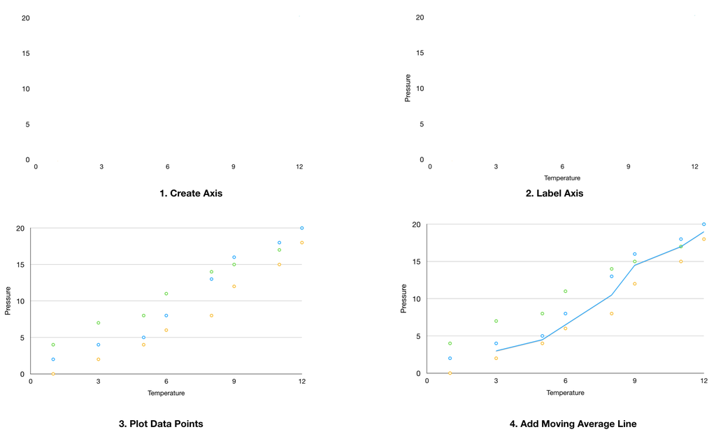

The Grammar of Graphics’ layers

The provided data is read from the csv file as a data frame:

```r
data <- read.csv(
  "/home/dthomas/Documents/KU/Advanced_Data_Modelling/private/RoadData.csv")
```

To get the accurate size of the data, print the number of observations (rows) and variables (columns):

```r
nrow(data)
```

```
## [1] 285331
```

```r
ncol(data)
```

```
## [1] 70
```

So there are 285,331 observations and 70 variables. Let’s see the variable names (column names):

```r
colnames(data)
```

```
##  [1] "accident_index"
##  [2] "vehicle_reference"
##  [3] "vehicle_type"
##  [4] "towing_and_articulation"
##  [5] "vehicle_manoeuvre"
##  [6] "vehicle_location.restricted_lane"
##  [7] "junction_location"
##  [8] "skidding_and_overturning"
##  [9] "hit_object_in_carriageway"
## [10] "vehicle_leaving_carriageway"
## [11] "hit_object_off_carriageway"
## [12] "X1st_point_of_impact"
## [13] "was_vehicle_left_hand_drive."
## [14] "journey_purpose_of_driver"
## [15] "sex_of_driver"
```

[output cut: 55 more lines]

This is an impressive amount of data and because of the large amount of variables, it’s wiser to clean the data on an as needed basis, i.e. just before feeding the data to each visualisation.

```r
library(dplyr)
library(ggplot2)
library(gridExtra)
```

# Data Visualisations

## Number of Accidents vs Sex of Driver vs Age of Driver

```r
unique(data$sex_of_driver)
```

```
## [1]  1  2  3 -1
```

Now let’s cross reference the code labels from the data description for ‘sex_of_driver’:

| code | label |
| --- | --- |
| 1 | Male |
| 2 | Female |
| 3 | Not known |
| -1 | Data missing or out of range |

So all observations with 3 and -1 are irrelevant and needs to be assigned as NA, which is a logical constant of length 1 that indicates a missing value in R. However, since we are only interested in the age of the driver, we can simply extract ages corresponding to male and females (1 & 2), which will omit all irrelevant values (3, -1).

Now let’s check for negative and unusual data values in the ‘age_of_driver’ variable, by obtaining it’s unique observations:

```r
unique(data$age_of_driver)
```

```
##  [1] 45 25 51 50 27 46 33 24 43 29 41 23 55 15 37 26 40 48 47 32 -1 31 30 13 34
## [26] 65 35 17 68 58 44 36 28 54 53 49 52 73 66 74 21 92 57 60 20 22 19 81 56 75
## [51]  9 18 38 42 10 14 69 62 72 59 70 87 61 71 64 67 39 77 79 63 76 80 78 11 16
## [76]  6 90 86 84 85  7 88 82 12 83 91  3 94  8 89  5 93  4  1 97 96
```

So there are negative values, -1, which needs to be filtered out. Let’s extract male and female driver ages as separate vectors, remove -1 age value and finally, create a data frame with two columns, age and sex, the latter being populated with ‘Male’ or ‘Female’ depending on the sex of the variable.

```r
male_ages <- data %>% filter(sex_of_driver == 1) %>%
  select(age_of_driver)
male_ages <- male_ages[male_ages > 0] # Filter out -1.
# Turn into data frame.
male_ages <- data.frame(male_ages, rep("Male", length(male_ages)))
colnames(male_ages) <- c("age", "sex") # Assign column names.

female_ages <- data %>% filter(sex_of_driver == 2) %>%
  select(age_of_driver)
female_ages <- female_ages[female_ages > 0] # Filter out -1.
# Turn into data frame.
female_ages <- data.frame(female_ages, rep("Female", length(female_ages)))
colnames(female_ages) <- c("age", "sex") # Assign column names.
```

Now let’s confirm the male and female observations doesn’t contain -1:

```r
any(unique(male_ages$age)[unique(male_ages$age) == -1])
```

```
## [1] FALSE
```

```r
any(unique(female_ages$age)[unique(female_ages$age) == -1])
```

```
## [1] FALSE
```

Now we can proceed to create a visualisation. The best way to visualise this information of age vs sex vs accidents is to create two separate histograms with respect to age, one for males, and one for females, and overlay the plots:

```r
# Combine male and female age data frame to a single data frame.
age_sex_df <- rbind(male_ages, female_ages)

require(wesanderson)
plot_age_sex <- ggplot(age_sex_df, aes(x = age, colour = sex, fill = sex)) +
  labs(x = "Age of Driver", y = "No. of Accidents", colour = "Sex of Driver",
       fill = "Sex of Driver") +
  scale_fill_manual(values = wes_palette("GrandBudapest1")) +
  scale_color_manual(values = wes_palette("GrandBudapest1")) +
  geom_histogram(alpha=0.5, position = "identity") +
  theme_classic()
```

Let’s also create another plot, where the day of the week is taken into account. Is there a particular day with more frequent accidents than others?

Let’s look at all the unique values present in the ‘day_of_week’ variable.

```r
unique(data$day_of_week)
```

```
## [1] 2 7 4 6 5 1 3
```

The values needs to be substituted with the following code labels from the data description:

| code | label |
| --- | --- |
| 1 | Sunday |
| 2 | Monday |
| 3 | Tuesday |
| 4 | Wednesday |
| 5 | Thursday |
| 6 | Friday |
| 7 | Saturday |

Substitute the values:

```r
data$day_of_week[data$day_of_week == 1] <- "Sunday"
data$day_of_week[data$day_of_week == 2] <- "Monday"
data$day_of_week[data$day_of_week == 3] <- "Tuesday"
data$day_of_week[data$day_of_week == 4] <- "Wednesday"
data$day_of_week[data$day_of_week == 5] <- "Thursday"
data$day_of_week[data$day_of_week == 6] <- "Friday"
data$day_of_week[data$day_of_week == 7] <- "Saturday"
```

Create the weekday plot:

```r
require(forcats)
require(wesanderson)
plot_days <- ggplot(data, aes(x = fct_rev(fct_infreq(day_of_week)),
                              fill = day_of_week)) +
  scale_fill_manual(values = c(rev(wes_palette("GrandBudapest1")),
                               wes_palette("GrandBudapest1"))) +
  labs(y = "No. of Accidents", x = "Weekday") +
  geom_histogram(stat = "count") +
  coord_flip() +
  theme_classic() +
  theme(legend.position = "none")
```

Now, is there a correlation with time?

```r
times <- data %>% select(accident_index, time)
times$time <- as.POSIXct(times$time, format="%H:%M:%S")

# Remove NA values
times <- na.omit(times)

plot_time <- ggplot(times, aes(x = time, fill = "lightcoral"))  +
  geom_density() +
  scale_x_datetime(date_breaks = "4 hour",
                       date_labels = "%I:%M %p") +
  labs(x = "Time", y = "Density") +
  theme_classic() +
  theme(legend.position = "none")
```

Now Let’s plot the visualisation

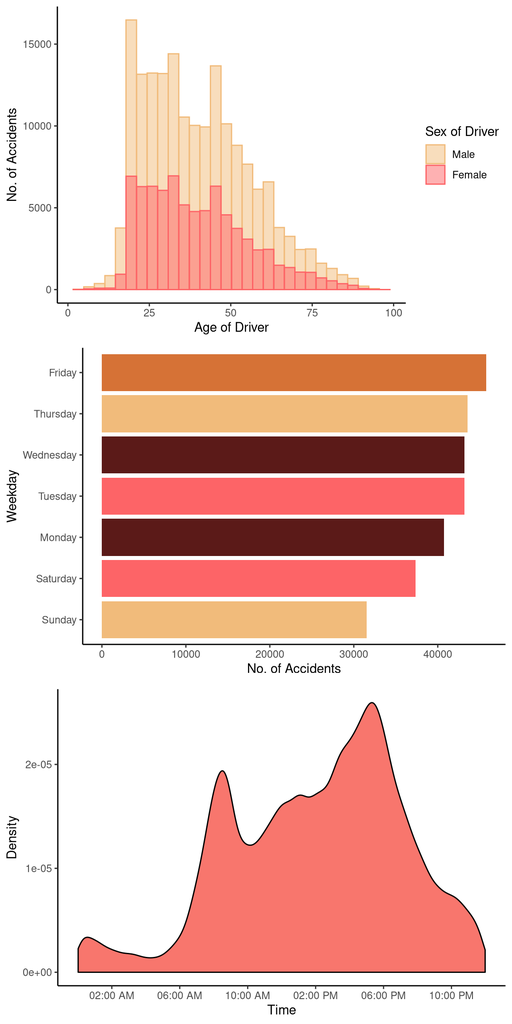

Driver Sex vs Driver Age vs No. of Accidents vs Day vs Time

As you can see from Figure 2, there were more male driver accidents than female driver accidents, where younger drivers make up for the majority of the accidents irrespective of sex. But, it is important to know that the conclusion from the visualisation doesn’t take how many male and female drivers there are in the UK. So if there are more male drivers than female drivers, statistically speaking, a higher proportion of accidents can be linked to male drivers.

## Geo-spatial plot of accidents

Are accidents more likely to occur in densely populated areas such as city centres? To answer this question, a Geo-spatial plot is required, with a density heat-map using the longitude and latitude data.

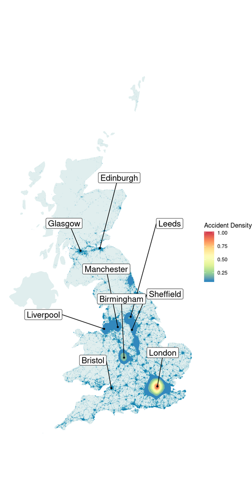

Geospatial plot of accidents

```r
library(maps)
library(mapproj)
library(RColorBrewer)
library(ggrepel)

UK <- map_data("world", "UK") # Obtain UK map.
UK_cities <- world.cities %>% filter(country.etc == "UK")

plot_geo_uk <- ggplot(data = UK, aes(x = long, y = lat, group = group)) +
  geom_polygon(fill = "azure2") +
  coord_map() +
  theme_void() +
  geom_point(aes(longitude, latitude), data = data, col = "deepskyblue3",
             alpha = 0.025, size = 1e-1, inherit.aes = FALSE) +


  # For the density heatmap:
  stat_density2d(aes(longitude, latitude, fill = ..level..),
                 data = data,
                 geom = "polygon",
             inherit.aes = FALSE) +
  labs(fill = "Accident Density") +
  scale_fill_gradientn(colours = rev(brewer.pal(7, "Spectral"))) +


  # Retrieve top 9 UK Cities, sorted by population density,
  # and add them as labels.
  geom_label_repel(data=UK_cities %>% arrange(pop) %>%
                     tail(9), aes(x=long, y=lat, label=name),
                     size=5, inherit.aes = FALSE, box.padding = 2.1,
                   max.iter = 50000, nudge_y = 1.25, nudge_x = 0.15) +
  geom_point( data=UK_cities%>% arrange(pop) %>%
                    tail(9), aes(x=long, y=lat), color="black",
                    size=1, inherit.aes = FALSE)
```

Looking at the data, we can easily see that major UK cities have more accidents than the UK countryside, this can be due to the areas being densely populated, which means more vehicles and people, which in-turn increases the risk of an accident.

## Districts with the highest amount of accidents

What are the top accident prone districts?

```r
# Get district ids with their occurence count; i.e. district id + how many times it occurs
districts <- as.data.frame(sort(table(data$local_authority_.district.), decreasing = TRUE))
colnames(districts)[1] <- "id"

# Get the top 20 district ids with the highest amount of accidents
districts <- districts[1:20,]

# To assign a String value instead of an integer ID
districts$id <- toupper(districts$id)

# Substitute district names
districts$id[districts$id == 300] <- "Birmingham"
districts$id[districts$id == 204] <- "Leeds"
districts$id[districts$id == 1] <- "Westminster"
districts$id[districts$id == 200] <- "Bradford"
districts$id[districts$id == 596] <- "Cornwall"
districts$id[districts$id == 926] <- "Glasgow City"
districts$id[districts$id == 91] <- "Liverpool"
districts$id[districts$id == 215] <- "Sheffield"
districts$id[districts$id == 635] <- "Wiltshire"
districts$id[districts$id == 9] <- "Lambeth"

districts$id[districts$id == 30] <- "Barnet"
districts$id[districts$id == 923] <- "Edinburgh, City of"
districts$id[districts$id == 5] <- "Tower Hamlets"
districts$id[districts$id == 27] <- "Ealing"
districts$id[districts$id == 203] <- "Kirklees"
districts$id[districts$id == 346] <- "Nottingham"
districts$id[districts$id == 211] <- "Doncaster"
districts$id[districts$id == 601] <- "Bristol, City of"
districts$id[districts$id == 10] <- "Wandsworth"
districts$id[districts$id == 169] <- "County Durham"


library(ggwordcloud)
# To get the same visualisation.
set.seed(21)
plot_word_cloud <- ggplot(districts, aes(label = id, size = Freq,
                                                color = id, replace = TRUE)) +
  geom_text_wordcloud_area() +
  scale_size_area(max_size = 16) +
  scale_color_manual(values = c(rev(wes_palette("GrandBudapest1")),
                               wes_palette("Moonrise2"),
                               wes_palette("Darjeeling1"),
                               wes_palette("FantasticFox1"),
                               wes_palette("Rushmore1")[3:5])) +
  theme_minimal()
```

Let’s also create a more detailed diagram.

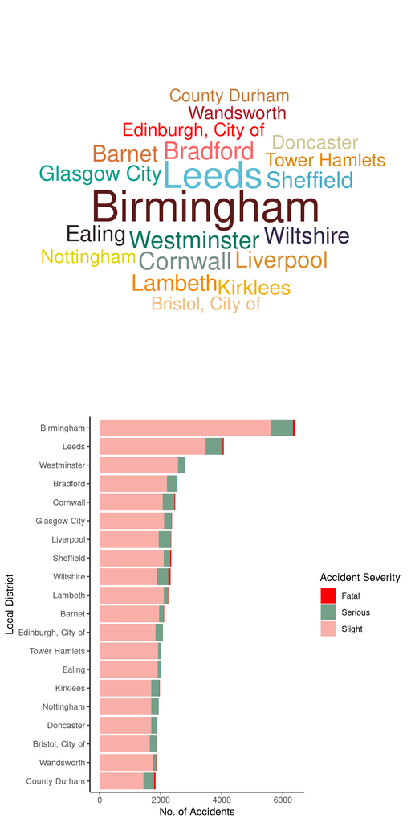

Most accidents prone districts with accident severity

```r
ld <- as.data.frame(sort(table(data$local_authority_.district.), decreasing = TRUE))
colnames(ld)[1] <- "id"
ld <- ld[1:20,]

districts <- data %>%
  filter(accident_severity == 1 || accident_severity == 2 || accident_severity == 3) %>%
  select(accident_severity, local_authority_.district.) %>%
  filter(local_authority_.district. %in% ld$id)

colnames(districts)[1] <- "severity"
colnames(districts)[2] <- "id"

# Substitute district names
districts$id[districts$id == 300] <- "Birmingham"
districts$id[districts$id == 204] <- "Leeds"
districts$id[districts$id == 1] <- "Westminster"
districts$id[districts$id == 200] <- "Bradford"
districts$id[districts$id == 596] <- "Cornwall"
districts$id[districts$id == 926] <- "Glasgow City"
districts$id[districts$id == 91] <- "Liverpool"
districts$id[districts$id == 215] <- "Sheffield"
districts$id[districts$id == 635] <- "Wiltshire"
districts$id[districts$id == 9] <- "Lambeth"

districts$id[districts$id == 30] <- "Barnet"
districts$id[districts$id == 923] <- "Edinburgh, City of"
districts$id[districts$id == 5] <- "Tower Hamlets"
districts$id[districts$id == 27] <- "Ealing"
districts$id[districts$id == 203] <- "Kirklees"
districts$id[districts$id == 346] <- "Nottingham"
districts$id[districts$id == 211] <- "Doncaster"
districts$id[districts$id == 601] <- "Bristol, City of"
districts$id[districts$id == 10] <- "Wandsworth"
districts$id[districts$id == 169] <- "County Durham"

districts$severity[districts$severity == 1] <- "Fatal"
districts$severity[districts$severity == 2] <- "Serious"
districts$severity[districts$severity == 3] <- "Slight"

require(forcats)
plot_hist_districts <- ggplot(districts,
                              aes(x = fct_rev(fct_infreq(id)), fill = as.factor(severity))) +
  geom_bar() +
  labs(x = "Local District", y = "No. of Accidents",
       fill = "Accident Severity") +
  scale_fill_manual(values =
                      rev(c(wes_palette("Royal2")[3],
                        wes_palette("Royal2")[5],
                        wes_palette("Darjeeling1")[1]))) +
  coord_flip() +
  theme_classic()
```